# Prediker boligpriser

Ola T. Øritsland

2019-12-22

# 1 Hent og klargjør data

```r
# Read all excel-files
ads_raw <- read_excel("input/ads.xlsx")
geo_raw <- read_excel("input/geo.xlsx")
zip_raw <- read_excel("input/zip.xlsx")
inc_raw <- read_excel("input/income.xlsx")
att_raw <- read_excel("input/attributes.xlsx")

# Select relevant columns
municipalities <- geo_raw  %>%
  select(ad_id, kommune_no, kommune_name, fylke_no, fylke_name, grunnkrets_name, delomraade_name, kommune_bydel_name, landsdel_name, naering_reg_name, centrality_name, police_reg_name, health_reg_name, eco_reg_name)

income <- inc_raw %>%
  rename(zip_no = postnr, avg_income = gjsnitt_inntekt, avg_fortune = gjsnitt_formue)

# Join data
ads <- ads_raw %>%
  select(-ad_title, -ad_address, -ad_url, -ad_img) %>%
  left_join(municipalities, by = "ad_id") %>%
  left_join(zip_raw, by = "ad_id") %>%
  left_join(income, by = "zip_no") %>%
  left_join(att_raw, by = "ad_id")

# Find mean of avg_income and avg_fortune by zip_no
avg_financials <- ads %>%
  group_by(zip_name) %>%
  summarise(impute_avg_income = mean(avg_income, na.rm = T), impute_avg_fortune = mean(avg_fortune, na.rm = T))

# If avg_income or avg_fortune is missing, replace with mean (above)
ads <- ads %>%
  left_join(avg_financials, by = "zip_name") %>%
  mutate(avg_income = if_else(is.na(avg_income), impute_avg_income, avg_income),
         avg_fortune = if_else(is.na(avg_fortune), impute_avg_fortune, avg_fortune)) %>%
  select(-impute_avg_income, - impute_avg_fortune)

# Remove unnecesarry objects
rm(ads_raw, geo_raw, zip_raw, inc_raw, att_raw, income, municipalities, avg_financials)
ads <- ads %>%
  replace_na(list(ad_debt = 0,
                  ad_expense = 0)) %>%
  mutate(
    ad_tot_price         = ad_price + ad_debt,
    ad_tot_price_per_sqm = ad_tot_price / ad_sqm,
    ad_bedrooms          = parse_number(ad_bedrooms)
  )

# Split in train/test
set.seed(42)

finn_split     <- initial_split(ads)
finn_train_raw <- training(finn_split)
finn_test_raw  <- testing(finn_split)
```

# 2 EDA

### 2.0.1 Map

```r
map <- ads %>%
  select(grunnkrets_name, ad_tot_price_per_sqm, lat, lng) %>%
  group_by(grunnkrets_name) %>%
  summarise(mean_lat = mean(lat, na.rm = T),
            mean_lng = mean(lng, na.rm = T),
            ad_tot_price_per_sqm = round(mean(ad_tot_price_per_sqm, na.rm = T)),
            n = n()) %>%

  # remove coords outside norway
  filter(mean_lat > 55)

# Create plot - ---------------------------------------------------------------------------
map %>%
  leaflet() %>%
  addTiles() %>%
  addCircles(lng = ~ mean_lng,
             lat = ~ mean_lat,
             color = ~colorQuantile("YlOrRd", ad_tot_price_per_sqm, n = 4)(ad_tot_price_per_sqm),
             fillOpacity = 1,
             popup = ~ paste("Name:", grunnkrets_name,
                             "Price per sqm:", ad_tot_price_per_sqm,
                             "Count:", n),
             radius = ~ad_tot_price_per_sqm/1e3) %>%
  addScaleBar(position = "bottomleft")
```

[interactive chart not shown]

### 2.0.2 Soverom

Datasettet (ads) består av 1935 NA’s for ‘ad_bedrooms’. Jeg imputer disse missing-verdiene for antall soverom som en funksjon av antall kvadratmeter. Denne funksjonen finner jeg ved å tilpasse en glm (ad_bedrooms ~ ad_sqm).

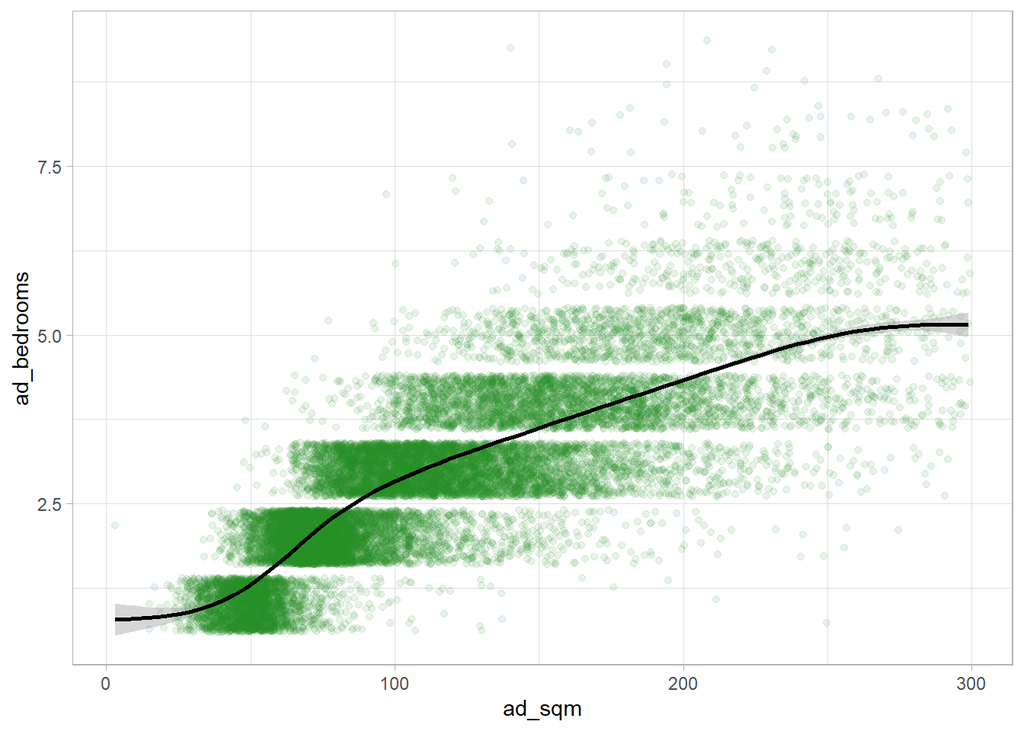

```r
ads %>%
  filter(ad_sqm < 300,
         ad_bedrooms < 10) %>%
  ggplot(aes(ad_sqm, ad_bedrooms)) +
  geom_jitter(color = 'forestgreen', alpha = 0.1) +
  geom_smooth(color = 'black') +
  theme_light()
```

### 2.0.3 Inntekt og formue

Datasettet inneholder 305 observasjoner med NA-verdier for inntekt og formue. Dette ser ut til å være et resultat av eldre postnr (zip_no) som ikke finnes i inntekts- og formuedataen. Noen av disse postnumrene har inntekts- og formuedata for poststed (zip_name). Jeg joiner derfor inn et snitt av disse som erstatter avg_income og avg_fortune dersom disse er NA. Deretter gjenstår det ca. 54 NAs. Disse blir imputet med median i step-funksjon i recipe.

### 2.0.4 ad_sqm_use

Har 3053 NAs. Jeg beregner en median av den relative forskjellen mellom ad_sqm og ad_sqm_use og bruker denne ratioen til å replace NA.

```r
ads %>%
  select(ad_sqm, ad_sqm_use) %>%
  mutate(diff_rate = ad_sqm_use/ad_sqm) %>%
  summarise(median = median(diff_rate, na.rm = T)) %>%
  pull()
```

```
## [1] 1.050633
```

### 2.0.5 Diverse

9 av variablene i datasettet (ads) har like mange NA’s (2937). De resterence NA-verdiene blir imputet med mode og median for hhv. faktor og numeriske features.

# 3 Datavask

## 3.1 Recipe

```r
xg_recipe <- recipe(ad_tot_price ~ ., data = finn_train_raw) %>%
  step_mutate(ad_home_type = fct_lump(ad_home_type, 4),
              ad_owner_type = fct_lump(ad_owner_type, 3),
              ad_bedrooms = if_else(is.na(ad_bedrooms),
                                    round(0.886 + ad_sqm * 0.02, 0),
                                    ad_bedrooms),
              ad_sqm_use = if_else(is.na(ad_sqm_use), ad_sqm * 1.05, ad_sqm_use),
              kommune_name  = fct_lump(kommune_name, 6),
              fylke_name    = fct_lump(fylke_name, 4),
              zip_name    = fct_lump(zip_name, 4)) %>%
  step_medianimpute(avg_fortune, avg_income) %>%
  step_modeimpute(all_nominal()) %>%
  step_medianimpute(all_numeric()) %>%
  step_integer(ad_home_type, ad_owner_type, kommune_name, fylke_name, zip_name) %>%
  step_rm(ad_id,
          ad_price,
          ad_tot_price_per_sqm,
          ad_debt,
          kommune_no,
          zip_no) %>%
  prep()
```

## 3.2 Bake

```r
finn_train <- bake(xg_recipe, finn_train_raw)
finn_test  <- bake(xg_recipe, finn_test_raw)
```

# 4 Tren modell

```r
xg_mod <- boost_tree(mode = "regression",
                     trees = 500) %>%

                     #min_n = 3) %>%
                     #tree_depth = 1,
                     #learn_rate = 0.15,
                     #loss_reduction = 0.9) %>%
  set_engine("xgboost", tree_method = "exact") %>%
  fit(ad_tot_price ~ ., data = finn_train)
```

# 5 Test modell

```r
prediction <- predict(xg_mod, finn_test) %>%
  bind_cols(finn_test_raw) %>%
  rename(estimate     = .pred,
         truth        = ad_tot_price) %>%
  mutate(abs_dev      = abs(truth - estimate),
         abs_dev_perc = abs_dev/truth)
```

# 6 Evaluer modell

## 6.1 Metrics

| .metric | .estimate |
| --- | --- |
| mape | 18.71 |
| rmse | 1130918.35 |
| mae | 610062.17 |
| rsq | 0.79 |

## 6.3 Variable importance

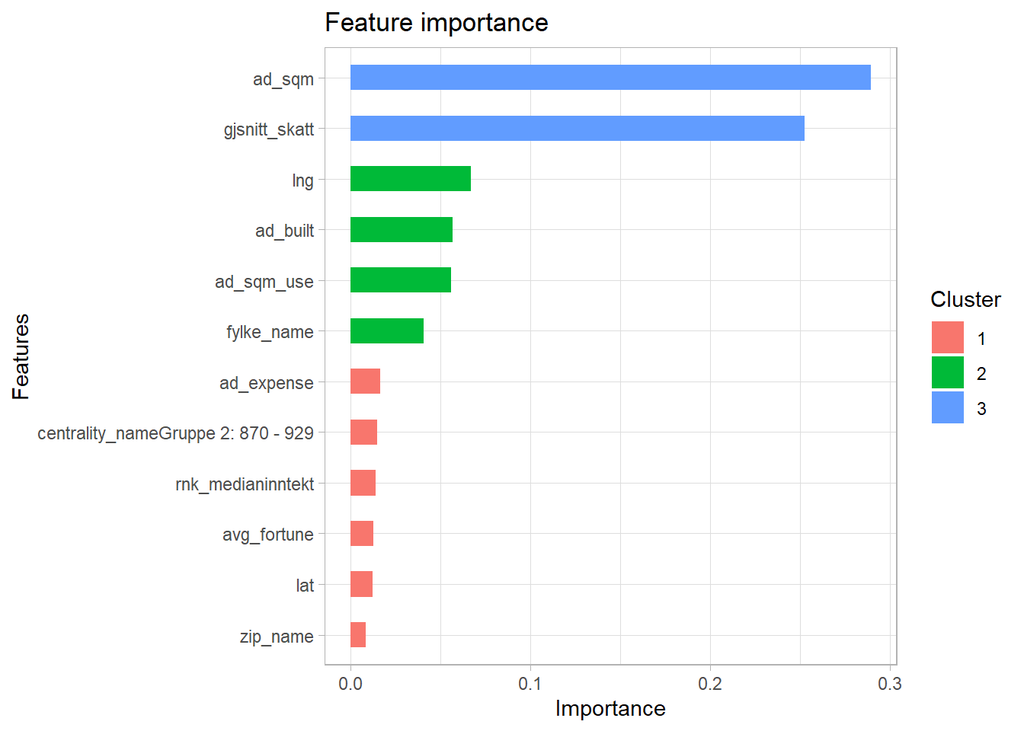

## 6.4 Distribution of predicted vs. observed

### 6.4.1 Aggregated

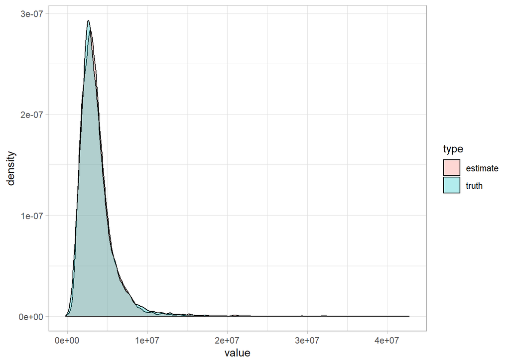

### 6.4.2 By fylke

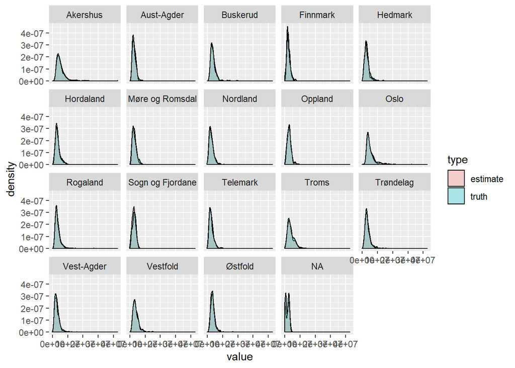